# clustMixType: User-Friendly Clustering of Mixed-Type Data in R

Clustering algorithms are designed to identify groups in data where the traditional emphasis has been on numeric data. In consequence, many existing algorithms are devoted to this kind of data even though a combination of numeric and categorical data is more common in most business applications. Recently, new algorithms for clustering mixed-type data have been proposed based on Huang’s k-prototypes algorithm. This paper describes the R package *clustMixType* which provides an implementation of k-prototypes in R.

Gero Szepannek (Stralsund University of Applied Sciences)  
2018-12-07

## 1 Introduction

Clustering algorithms are designed to identify groups in data where the traditional emphasis has been on numeric data. In consequence, many existing algorithms are devoted to this kind of data even though a combination of numeric and categorical data is more common in most business applications. For an example in the context of credit scoring, see, e.g. Szepannek (2017). The standard way to tackle mixed-type data clustering problems in R is to use either (1) Gower distance (Gower 1971) via the [*gower*](https://CRAN.R-project.org/package=gower) package (van der Loo 2017) or the `daisy(method = "gower")` in the [*cluster*](https://CRAN.R-project.org/package=cluster) package (Maechler et al. 2018); or (2) Hierarchical clustering through `hclust()` or the `agnes()` function in *cluster*. Recent innovations include the package [*CluMix*](https://CRAN.R-project.org/package=CluMix) (Hummel et al. 2017), which combines both Gower distance and hierarchical clustering with some functions for visualization. As this approach requires computation of distances between any two observations, it is not feasible for large data sets. The package [*flexclust*](https://CRAN.R-project.org/package=flexclust) (Leisch 2006) offers a flexible framework for k-centroids clustering through the function `kcca()` which allows for arbitrary distance functions. Among the currently pre-implemented `kccaFamilies`, there is no distance measure for mixed-type data. Alternative approaches based on expectation-maximization are given by the function `flexmixedruns()` in the [*fpc*](https://CRAN.R-project.org/package=fpc) package (Hennig 2018) and the package [*clustMD*](https://CRAN.R-project.org/package=clustMD) (McParland 2017). Both require the variables in the data set to be ordered according to their data type, and that categorical variables to be preprocessed into integers. The clustMD algorithm (McParland and Gormley 2016) also allows ordinal variables but is quite computationally intensive. The [*kamila*](https://CRAN.R-project.org/package=kamila) package (Foss and Markatou 2018) implements the KAMILA clustering algorithm which uses a kernel density estimation technique in the continuous domain, a multinomial model in the categorical domain, and the Modha-Spangler weighting of variables in which categorical variables have to be transformed into indicator variables in advance (Modha and Spangler 2003).

Recently, more algorithms for clustering mixed-type data have been proposed in the literature ((He et al. 2005; Amir and Dey 2007; Pham et al. 2011; Dutta et al. 2012; Ji et al. 2012, 2013, 2015; Lim et al. 2012; Foss et al. 2016; HajKacem et al. 2016; Liu et al. 2017)). Many of these are based on the idea of Huang’s k-prototypes algorithm (Huang 1998). The rest of this paper describes the R package [*clustMixType*](https://CRAN.R-project.org/package=clustMixType) (Szepannek 2018), which provides up to the author’s knowledge the first implementation of this algorithm in R. The k-modes algorithm (Huang 1997a) has been implemented in the package [*klaR*](https://CRAN.R-project.org/package=klaR) ((Weihs et al. 2005; Roever et al. 2018)) for purely categorical data, but not for the mixed-data case. The rest of the paper is organized as follows: A brief description of the algorithm is followed by the functions in the *clustMixType* package. Some extensions to the original algorithm are discussed and as well as a worked example application.

## 2 k-prototypes clustering

The k-prototypes algorithm belongs to the family of partitional cluster algorithms. Its objective function is given by:
$$E = \sum_{i=1}^n \sum_{j=1}^k u_{ij} d\left(x_i, \mu_j\right),$$
where $x_i, i = 1, \ldots, n$ are the observations in the sample, $\mu_j, j = 1, \ldots, k$ are the cluster prototype observations, and $u_{ij}$ are the elements of the binary partition matrix $U_{n \times k}$ satisfying $\sum_{j=1}^k u_{ij} = 1,\, \forall\, i$. The distance function is given by:
$$d(x_i, \mu_j) = \sum_{m=1}^q \left(x_i^m - \mu_j^m\right)^2 + \lambda \sum_{m=q+1}^p \delta\left(x_i^m,\mu_j^m\right).$$
where $m$ is an index over all variables in the data set where the first $q$ variables are numeric and the remaining $p-q$ variables are categorical. Note that $\delta(a,b) = 0$ for $a=b$ and $\delta(a,b) = 1$ for $a \ne b$, and $d()$ corresponds to weighted sum of Euclidean distance between two points in the metric space and simple matching distance for categorical variables (i.e. the count of mismatches). The trade off between both terms can be controlled by the parameter $\lambda$ which has to be specified in advance as well as the number of clusters $k$. For larger values of $\lambda$, the impact of the categorical variables increases. For $\lambda = 0$, the impact of the categorical variables vanishes and only numeric variables are taken into account, just as in traditional k-means clustering.

The algorithm iterates in a manner similar to the k-means algorithm (MacQueen 1967) where for the numeric variables the mean and the categorical variables the mode minimizes the total within cluster distance. The steps of the algorithm are:

1. Initialization with random cluster prototypes.
2. For each observation do:
   1. Assign observations to its closest prototype according to $d()$.
   2. Update cluster prototypes by cluster-specific means/modes for all variables.
3. As long as any observations have swapped their cluster assignment in 2 or the maximum number of iterations has not been reached: repeat from 2.

## 3 k-prototypes in R

An implementation of the k-prototypes algorithm is given by the function

```r
    kproto(x, k, lambda = NULL, iter.max = 100, nstart = 1, na.rm = TRUE)
```

where

- `x` is a data frame with both numeric and factor variables. As opposed to other existing R packages, the factor variables do not need to be preprocessed in advance and the order of the variables does not matter.
- `k` is the number of clusters which has to be pre-specified. Alternatively, it can also be a vector of observation indices or a data frame of prototypes with the same columns as `x`. If ever at the initialization or during the iteration process identical prototypes do occur, the number of clusters will be reduced accordingly.
- `lambda` $>0$ is a real valued parameter that controls the trade off between Euclidean distance for numeric variables and simple matching distance for factor variables for cluster assignment. If no $\lambda$ is specified the parameter is set automatically based on the data and a heuristic using the function `lambdaest()`. Alternatively, a vector of length `ncol(x)` can be passed to `lambda` (cf. Section on 4).
- `iter.max` sets the maximum number of iterations, just as in `kmeans()`. The algorithm may stop prior to `iter.max` if no observations swap clusters.
- `nstart` may be set to a value $> 1$ to run k-prototypes multiple times. Similar to k-means, the result of k-prototypes depends on its initialization. If `nstart` $> 1$, the best solution (i.e. the one that minimizes $E$) is returned.
- Generally, the algorithm can deal with missing data but as a default `NA`s are removed by `na.rm = TRUE`.

Two additional arguments, `verbose` and `keep.data`, can control whether information on missing values should be printed and whether the original data should be stored in the output object. The `keep.data=TRUE` option is required for the default call to the `summary()` function, but in case of large `x`, it can be set to `FALSE` to save memory.

The output is an object of class `"kproto"`. For convenience, the elements are designed to be compatible with those of class `"kmeans"`:

- `cluster` is an integer vector of cluster assignments
- `centers` stores the prototypes in a data frame
- `size` is a vector of corresponding cluster sizes
- `withinss` returns the sum over all within cluster distances to the prototype for each cluster
- `tot.withinss` is their sum over all clusters which corresponds to the objective function $E$
- `dists` returns a matrix of all observations’ distances to all prototypes in order to investigate the crispness of the clustering
- `lambda` and `iter` store the specified arguments of the function call
- `trace` lists the objective function $E$ as well as the number of swapped observations during the iteration process

Unlike `"kmeans"`, the `"kproto"` class is accompanied corresponding `predict()` and `summary()` methods. The `predict.kproto()` method can be used to assign clusters to new data. Like many of its cousins, it is called by

```r
    predict(object, newdata)
```

The output again consists of two elements: a vector `cluster` of cluster assignments and a matrix `dists` of all observations’ distances to all prototypes.

The investigation resulting from a cluster analysis typically consists of identifying the differences between the clusters, or in this specific case, those of the k prototypes. For practical applications besides the cluster sizes, it is of further interest to take into account the homogeneity of the clusters. For numeric variables, this can be done by calling the R function `summary()`. For categorical variables the representativity of the prototypes is given their frequency distribution obtained by `prop.table()`. The `summary.kproto()` method applies these methods to the variables conditional to the resulting clusters and returns a comparative results table of the clusters for each variable.

The summary is not restricted to the training data but it can further be applied to new data by calling `summary(object, data)` where `data` are new data that will be internally passed to the `predict()` method on the `object` of class `"kproto"`. If no new data is specified (default: `data = NULL`), the function requires `object` to contain the original data (argument `keep.data = TRUE`). In addition, a function

```r
    clprofiles(object, x, vars = NULL)
```

supports the analysis of the clusters by visualization of cluster profiles based on an `object` of class `"kproto"` and data `x`. Note that the latter may also have different variables compared to the original data, such as for profiling variables that were not used for clustering. As opposed to `summary.kproto()`, no new prediction is done but the cluster assignments of the `"kproto"` object given by `object$cluster` are used. For this reason, the observations in `x` must be the same as in the original data. Via the `vars` argument, a subset of variables can be specified either by a vector of indices or variable names. Note that `clprofiles()` is not restricted to objects of class `"kproto"` but can also be applied to other cluster objects as long as they are of a `"kmeans"`-like structure with elements `cluster` and `size`.

## 4 Extensions to the original algorithm

For unsupervised clustering problems, the user typically has to specify the impact of the specific variables on the desired cluster solution which is controlled by the parameter $\lambda$. Generally, small values $\lambda \sim 0$ emphasize numeric variables and will lead to results similar to standard k-means whereas larger values of $\lambda$ lead to an increased influence of categorical variables. In Huang (1997b), the average standard deviation $\sigma$ of the numeric variables is the suggested choice for $\lambda$ and in some practical applications in the paper values of $\frac{1}{3}\sigma \le \lambda \le \frac{2}{3}\sigma$ are used. The function

```r
    lambdaest(x, num.method = 1, fac.method = 1, outtype = "numeric")
```

provides different data based heuristics for the choice of $\lambda$: The average variance $\sigma^2$ (`num.method = 1`) or standard deviation $\sigma$ (`num.method = 2`) over all numeric variables is related to the average concentration $h_{cat}$ of all categorical variables. We compute $h_{cat}$ by averaging either $h_m = 1-\sum_c p_{mc}^2$ (`fac.method = 1`) or $h_m = 1-\max_c p_{mc}$ (`fac.method = 2`) over all variables $m$ where $c$ are the categories of the factor variables. We set $\lambda = \frac{\sigma^t}{h_{cat}}, t \in\{1,2\}$ as a user-friendly default choice to prevent over-emphasizing either numeric or categorical variables. If `kproto()` is called without specifying `lambda`, the parameter is automatically set using `num.method = fac.method = 1`. Note that this should be considered a starting point for further analysis; the explicit choice of $\lambda$ should be done carefully based on the application context.

Originally, $\lambda$ is real-valued, but in order to up- or downweight the relevance of single variables in a specific application context, the function `kproto()` is extended to accept vectors as input where each element corresponds to a variable specific weight, $\lambda_m$. The formula for distance computation changes to:
$$d(x_i, p_j) = \sum_{m=1}^q \lambda_m \left(x_i^m - \mu_j^m\right)^2 + \sum_{m=q+1}^p \lambda_m \delta\left(x_i^m,\mu_j^m\right).$$
Note that the choice of $\lambda$ only affects the assignment step for the observations but not the computation of the prototype given a cluster of observations. By changing the `outtype` argument into a vector, the function `lambdaest()` returns a vector of $\lambda_m$s. In order to support a user-specific definition of $\lambda$ based on the variables’ variabilities, `outtype = "variation"` returns a vector of original values of variability for all variables in terms of the quantities described above.

An issue of great practical relevance is the ability of an algorithm to deal with missing values which can be solved by an intuitive extension of k-prototypes. During the iterations, cluster prototypes can be updated by ignoring `NA`s: Both means for numeric variables as well as modes for factors can be computed based on the available data. Similarly, distances for cluster assignment can be computed for each observation based on the available variables only. This not only allows cluster assignment for observations with missing values, but already takes these observations into account when the clusters are formed. By using `kproto()`, this can be obtained by setting the argument `na.rm = FALSE`. Note that in practice, this option should be handled with care unless the number of missing values is very small. The representativeness of a prototype might become questionable if its means and modes do not represent the major part of the cluster’s observations.

Finally, a modification of the original algorithm presented in Section 2 allows for vector-wise computation of the iteration steps, reducing computation time. The update of the prototypes is not done after each new cluster assignment, but once each time the whole data set has been reassigned. The modified k-prototypes algorithm consists of the following steps:

1. Initialization with random cluster prototypes.
2. Assign all observations to its closest prototype according to $d()$.
3. Update cluster prototypes.
4. As long as any observations have swapped their cluster assignment in 2 or the maximum number of iterations has not been reached: repeat from 2.

## 5 Example

As an example, data `x` with two numeric and two categorical variables are simulated according to the documentation in `?kproto`: Using `set.seed(42)`, four clusters $j = 1, \ldots, 4$ are designed such that two pairs can be separated only by their numeric variables and the other two pairs only by their categorical variables. The numeric variables are generated as normally distributed random variables with cluster specific means $\mu_1 = \mu_2 = -\mu_3 = -\mu_4 = \Phi^{-1}(0.9)$ and the categorical variables have two levels ($A$ and $B$) each with a cluster specific probability $p_1(A) = p_3(A) = 1-p_2(A) = 1-p_4(A) = 0.9$. Table 1 summarizes the clusters. It can be seen that both numeric and categorical variables are needed in order to identify all four clusters.

Table 1: Separation of clusters in the example.

| cluster | numeric | categorical |
| --- | --- | --- |
| 1 | + | + |
| 2 | + | - |
| 3 | - | + |
| 4 | - | - |

Given the knowledge that there are four clusters in the data, a straightforward call for k-prototypes clustering of the data will be:

```r
kpres <- kproto(x = x, k = 4)
kpres                 # output 1
summary(kpres)        # output 2
library(wesanderson)
par(mfrow=c(2,2))
clprofiles(kpres, x, col = wes_palette("Royal1", 4, type = "continuous"))  # figure 1
```

The resulting output is of the form:

```r
# Output 1:

Numeric predictors: 2
Categorical predictors: 2
Lambda: 5.52477

Number of Clusters: 4
Cluster sizes: 100 95 101 104
Within cluster error: 332.909 267.1121 279.2863 312.7261

Cluster prototypes:
    x1 x2         x3        x4
92   A  A  1.4283725  1.585553
54   A  A -1.3067973 -1.091794
205  B  B -1.4912422 -1.654389
272  B  B  0.9112826  1.133724

# Output 2 (only for variable x1 and x3):

x1

cluster     A     B
      1 0.890 0.110
      2 0.905 0.095
      3 0.069 0.931
      4 0.144 0.856

-----------------------------------------------------------------

x3
     Min. 1st Qu.  Median    Mean 3rd Qu.   Max.
1 -0.7263  0.9314  1.4080  1.4280  2.1280 4.5110
2 -3.4200 -1.9480 -1.3170 -1.3070 -0.6157 2.2450
3 -4.2990 -2.0820 -1.4600 -1.4910 -0.7178 0.2825
4 -1.5300  0.2788  0.9296  0.9113  1.5000 3.1480

-----------------------------------------------------------------
```

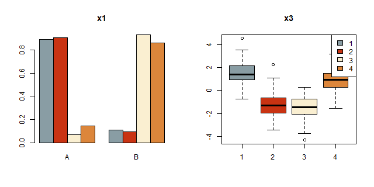

Figure 1: Cluster profiles for variables `x1` and `x3`.

By construction, taking into account either only numeric (k-means) or only factor variables (k-modes) will not be able to identify the underlying cluster structure without further preprocessing of the data in this example. A performance comparison using the Rand index (Rand 1971) as computed by the package [*clusteval*](https://CRAN.R-project.org/package=clusteval) (Ramey 2012) results in rand indices of $0.728$ (k-means) and $0.733$ (k-modes). As already seen above, the prototypes as identified by *clustMixType* do represent the true clusters quite well, as the corresponding Rand index improves to $0.870$.

```r
library(klaR)
library(clusteval)

kmres  <- kmeans(x[,3:4], 4) # kmeans using numerics only
kmores <- kmodes(x[,1:2], 4) # kmodes using factors only

cluster_similarity(kpres$cluster, clusid, similarity = "rand")
cluster_similarity(kmres$cluster, clusid, similarity = "rand")
cluster_similarity(kmores$cluster, clusid, similarity = "rand")
```

The runtime of `kproto()` is linear in the number of observations (Huang 1997b) and thus it is also applicable to large data sets. Figure 2 (left) shows the behaviour of the runtime for 50 repeated simulations of the example data with an increased number of variables (half of them numeric and half of them categorical). It is possible to run `kproto()` for more than hundred variables which is far beyond most practical applications where human interpretation of the resulting clusters is desired. Note that *clustMixType* is written in R and currently no C++ code is used to speed up computations which could be a subject of future work.

In order to determine the appropriate number of clusters for a data set, we can use the standard scree test. In this case, the objective function $E$ is given by the output’s `tot.withinss` element. The `kproto()` function is run multiple times for varying numbers of clusters (but fixed $\lambda$) and the number of clusters is chosen as the minimum $k$ from whereon no strong improvements of $E$ are possible. In Figure 2 (right), an elbow is visible at the correct number of clusters in the sample data; recall that we simulatd from four clusters. Note that from a practitioner’s point of view, an appropriate solution requires clusters that are well represented by their prototypes. For this reason, the choice of the number of clusters should further take into account a homogeneity analysis of the clusters as returned by `summary()`, `clprofiles()` or the `withinss` element of the `"kproto"` output.

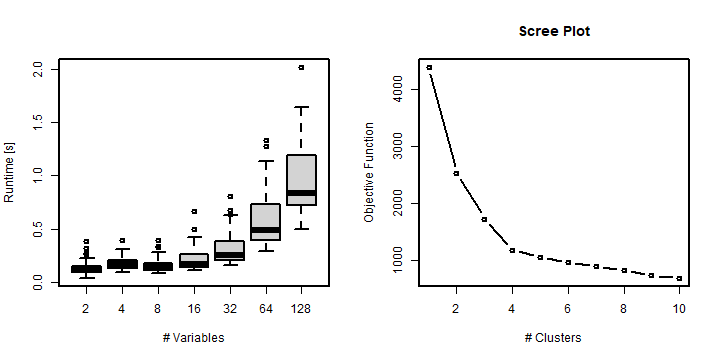

Figure 2: Runtime for increasing number of variables (left) and screeplot (right).

```r
Es <- numeric(10)
for(i in 1:10){
    kpres <- kproto(x, k = i, nstart = 5)
    Es[i] <- kpres$tot.withinss
}
plot(1:10, Es, type = "b", ylab = "Objective Function", xlab = "# Clusters",
     main = "Scree Plot")  # figure 2
```

## 6 Summary

The *clustMixType* package provides a user-friendly way for clustering mixed-type data in R given by the k-prototypes algorithm. As opposed to other packages, no preprocessing of the data is necessary, and in contrast to standard hierarchical approaches, it is not restricted to moderate data sizes. Its application requires the specification of two hyperparameters: the number of clusters $k$ as well as a second parameter $\lambda$ that controls the interplay of the different data types for distance computation. As an extension to the original algorithm, the presented implementation allows for a variable-specific choice of $\lambda$ and can deal with missing data. Furthermore, with regard to business purposes, functions for profiling a cluster solution are presented.

This paper is based on *clustMixType* version 0.1-36. Future work may focus on the development of further guidance regarding the choice of the parameter $\lambda$, such as using stability considerations (cf. Hennig 2007), or the investigation of possible improvements in computation time by integrating *Rcpp* ((Eddelbuettel and François 2011; Eddelbuettel et al. 2018)).

### 6.1 Supplementary materials

Supplementary materials are available in addition to this article. It can be downloaded at RJ-2018-048.zip

### 6.2 CRAN packages used

gower, cluster, CluMix, flexclust, fpc, clustMD, kamila, clustMixType, klaR, wesanderson, clusteval

### 6.3 CRAN Task Views implied by cited packages

Cluster, Environmetrics, MachineLearning, Robust

A. Amir and L. Dey. A k-mean clustering algorithm for mixed numeric and categorical data. *Data and Knowledge Engineering*, 63: 88–96, 2007. DOI 10.1016/j.datak.2007.03.016.

D. Dutta, P. Dutta and J. Sil. Data clustering with mixed features by multi objective genetic algorithm. In *12th international conference on hybrid intelligent systems (HIS)*, pages. 336–341 2012. DOI 10.1109/HIS.2012.6421357.

D. Eddelbuettel, R. Francois, J. Allaire, K. Ushey, Q. Kou, N. Russell, D. Bates and J. Chambers. *Rcpp: Seamless r and c++ integration.* 2018. URL https://CRAN.R-project.org/package=Rcpp. R package version 0.12.18.

D. Eddelbuettel and R. François. Rcpp: Seamless R and C++ integration. *Journal of Statistical Software*, 40(8): 1–18, 2011. URL http://www.jstatsoft.org/v40/i08/.

A. Foss and M. Markatou. *Kamila: Methods for clustering mixed-type data.* 2018. URL https://CRAN.R-project.org/package=kamila. R package version 0.1.1.2.

A. Foss, M. Markatou, B. Ray and A. Heching. A semiparametric method for clustering mixed data. *Machine Learning*, 105(3): 419–458, 2016. DOI 10.1007/s10994-016-5575-7.

J. Gower. A general coefficient of similarity and some of its properties. *Biometrics*, 27: 857–874, 1971. DOI 10.2307/2528823 .

M. A. B. HajKacem, C.-E. B. N’cir and N. Essoussi. An accelerated MapReduce-based k-prototypes for big data. In *Software technologies: Applications and foundations 2016, springer LNCS 9946*, Eds P. Milazzo, D. Varro and M. Wimmer pages. 13–25 2016. DOI 10.1007/978-3-319-50230-4_2.

Z. He, X. Xu and S. Deng. A cluster ensemble method for clustering categorical data. *Information Fusion*, 6: 2005. DOI 10.1016/j.inffus.2004.03.001.

C. Hennig. Cluster-wise assessment of cluster stability. *Computational Statistics and Data Analysis*, 52: 258–271, 2007. DOI 10.1016/j.csda.2006.11.025.

C. Hennig. *Fpc: Flexible procedures for clustering.* 2018. URL https://CRAN.R-project.org/package=fpc. R package version 2.1-11.1.

Z. Huang. A fast clustering algorithm to cluster very large categorical data sets in data mining. In *Proceedings of the SIGMOD workshop on research issues on data mining and knowledge discovery*, pages. 1–8 1997a.

Z. Huang. Clustering large data sets with mixed numeric and categorical values. In *Proceedings of the first pacific asia knowledge discovery and data mining conference, singapore*, pages. 21–34 1997b.

Z. Huang. Extensions to the k-means algorithm for clustering large data sets with categorical variables. *Data Mining and Knowledge Discovery*, 2: 283–304, 1998. DOI 10.1023/A:1009769707641.

M. Hummel, D. Edelmann and A. Kopp-Schneider. *CluMix: Clustering and visualization of mixed-type data.* 2017. URL https://CRAN.R-project.org/package=CluMix. R package version 2.1.

J. Ji, T. Bai, C. Zhou, C. Maa and Z. Wang. An improved k-prototypes clustering algorithm for mixed numeric and categorical data. *Neurocomputing*, 120: 590–596, 2013. DOI 10.1016/j.neucom.2013.04.011.

J. Ji, W. Pang, Y. Zheng, Z. Wang, Z. Ma and L. Zhang. A novel cluster center initialization method for the k-prototypes algorithms using centrality and distance. *Applied Mathematics and Information Sciences*, 9: 2933–2942, 2015. DOI 10.12785/amis/090621.

J. Ji, W. Pang, C. Zhou, X. Han and Z. Wang. A fuzzy k-prototype clustering algorithm for mixed numeric and categorical data. *Knowledge-Based Systems*, 30: 129–135, 2012. DOI 10.1016/j.knosys.2012.01.006.

F. Leisch. A toolbox for k-centroids cluster analysis. *Computational Statistics and Data Analysis*, 51(2): 526–544, 2006. DOI 10.1016/j.csda.2005.10.006.

J. Lim, J. Jun, S. H. Kim and D. McLeod. A framework for clustering mixed attribute type datasets. In *Proceeding of the fourth international conference on emerging databases (EDB)*, 2012.

S.-H. Liu, B. Zhou, D. Huang and L. Shen. Clustering mixed data by fast search and find of density peaks. *Mathematical Problems in Engineering*, 2017: 1–7, 2017. DOI 10.1155/2017/5060842.

J. MacQueen. Some methods for classification and analysis of multivariate observations. In *Proc. 5th berkeley symp. Math stat and prob*, Eds L. Le Cam and J. Neyman pages. 281–297 1967.

M. Maechler, P. Rousseeuw, A. Struyf, M. Hubert and K. Hornik. *Cluster: Cluster analysis basics and extensions.* 2018. URL https://CRAN.R-project.org/package=cluster. R package version 2.0.7-1.

D. McParland. *clustMD: Model based clustering for mixed data.* 2017. URL https://CRAN.R-project.org/package=clustMD. R package version 1.2.1.

D. McParland and I. Gormley. Model based clustering for mixed data: clustMD. *Advances in Data Analysis and Classification*, 10(2): 155–170, 2016. DOI 10.1007/s11634-016-0238-x.

D. Modha and S. Spangler. Feature weighting in k-means clustering. *Machine Learning*, 52(3): 217–237, 2003. DOI 10.1023/A:1024016609528.

D. Pham, M. Suarez-Alvarez and Y. I. Prostov. Random search with k-prototypes algorithm for clustering mixed datasets. *Proceedings of The Royal Society A: Mathematical, Physical and Engineering Sciences*, 467: 2387–2403, 2011. DOI 10.1098/rspa.2010.0594.

K. Ram and H. Wickham. *Wesanderson: A wes anderson palette generator.* 2018. URL https://CRAN.R-project.org/package=wesanderson. R package version 0.3.6.

J. A. Ramey. *Clusteval: Evaluation of clustering algorithms.* 2012. URL https://CRAN.R-project.org/package=clusteval. R package version 0.1.

W. Rand. Objective criteria for the evaluation of clustering methods. *Journal of the American Statistical Association*, 66: 846–850, 1971. DOI 10.2307/2284239.

C. Roever, N. Raabe, K. Luebke, U. Ligges, G. Szepannek and M. Zentgraf. *klaR: Classification and visualization.* 2018. URL https://CRAN.R-project.org/package=klaR. R package version 0.6-14.

G. Szepannek. *clustMixType: K-prototypes clustering for mixed variable-type data.* 2018. URL https://CRAN.R-project.org/package=clustMixType. R package version 0.1-36.

G. Szepannek. On the practical relevance of modern machine learning algorithms for credit scoring applications. *WIAS Report Series*, 29: 88–96, 2017. DOI 10.20347/wias.report.29.

M. van der Loo. *Gower: Gower’s distance.* 2017. URL https://CRAN.R-project.org/package=gower. R package version 0.1.2.

C. Weihs, U. Ligges, K. Luebke and N. Raabe. klaR analyzing german business cycles. In *Data analysis and decision support*, Eds D. Baier, R. Decker and L. Schmidt-Thieme pages. 335–343 2005. Berlin: Springer-Verlag. DOI 10.1007/3-540-28397-8_36.